# Pasaporte_Lab3.Rmd

MEN-GUE

2026-03-12

## Descripción de las Variables

Data summary

| Name | df |
| --- | --- |
| Number of rows | 171748 |
| Number of columns | 80 |
| _______________________ |  |
| Column type frequency: |  |
| character | 37 |
| logical | 1 |
| numeric | 42 |
| ________________________ |  |
| Group variables | None |

**Variable type: character**

| skim_variable | n_missing | complete_rate | min | max | empty | n_unique | whitespace |
| --- | --- | --- | --- | --- | --- | --- | --- |
| listing_url | 0 | 1.00 | 30 | 48 | 0 | 171748 | 0 |
| last_scraped | 0 | 1.00 | 10 | 10 | 0 | 12 | 0 |
| source | 0 | 1.00 | 11 | 15 | 0 | 2 | 0 |
| name | 0 | 1.00 | 1 | 253 | 0 | 163402 | 0 |
| description | 0 | 1.00 | 0 | 1009 | 4363 | 142952 | 0 |
| neighborhood_overview | 0 | 1.00 | 0 | 1177 | 86851 | 61258 | 0 |
| picture_url | 0 | 1.00 | 60 | 156 | 0 | 167625 | 0 |
| host_url | 0 | 1.00 | 36 | 43 | 0 | 78818 | 0 |
| host_name | 0 | 1.00 | 0 | 45 | 876 | 22307 | 0 |
| host_since | 0 | 1.00 | 0 | 10 | 876 | 5975 | 0 |
| host_location | 0 | 1.00 | 0 | 44 | 39514 | 2871 | 0 |
| host_about | 1 | 1.00 | 0 | 7091 | 67271 | 41618 | 28 |
| host_response_time | 0 | 1.00 | 0 | 18 | 876 | 6 | 0 |
| host_response_rate | 0 | 1.00 | 0 | 4 | 876 | 85 | 0 |
| host_acceptance_rate | 0 | 1.00 | 0 | 4 | 876 | 103 | 0 |
| host_is_superhost | 0 | 1.00 | 0 | 1 | 2150 | 3 | 0 |
| host_thumbnail_url | 0 | 1.00 | 0 | 131 | 876 | 76194 | 0 |
| host_picture_url | 0 | 1.00 | 0 | 159 | 876 | 76221 | 0 |
| host_neighbourhood | 0 | 1.00 | 0 | 106 | 30110 | 2832 | 0 |
| host_verifications | 0 | 1.00 | 2 | 32 | 0 | 8 | 0 |
| host_has_profile_pic | 0 | 1.00 | 0 | 1 | 878 | 3 | 0 |
| host_identity_verified | 0 | 1.00 | 0 | 1 | 876 | 3 | 0 |
| neighbourhood | 0 | 1.00 | 0 | 32 | 86851 | 3 | 0 |
| neighbourhood_cleansed | 0 | 1.00 | 3 | 97 | 0 | 855 | 0 |
| neighbourhood_group_cleansed | 50683 | 0.70 | 4 | 20 | 0 | 17 | 0 |
| property_type | 0 | 1.00 | 3 | 34 | 0 | 119 | 0 |
| room_type | 0 | 1.00 | 10 | 15 | 0 | 4 | 0 |
| bathrooms_text | 0 | 1.00 | 0 | 17 | 585 | 65 | 0 |
| amenities | 0 | 1.00 | 2 | 2811 | 0 | 149888 | 0 |
| price | 89381 | 0.48 | 0 | 10 | 6121 | 2321 | 0 |
| has_availability | 0 | 1.00 | 0 | 1 | 10044 | 3 | 0 |
| calendar_last_scraped | 0 | 1.00 | 10 | 10 | 0 | 12 | 0 |
| first_review | 0 | 1.00 | 0 | 10 | 40287 | 5266 | 0 |
| last_review | 0 | 1.00 | 0 | 10 | 40287 | 3904 | 0 |
| license | 10533 | 0.94 | 0 | 203 | 81745 | 52058 | 0 |
| instant_bookable | 0 | 1.00 | 1 | 1 | 0 | 2 | 0 |
| city | 0 | 1.00 | 6 | 25 | 0 | 10 | 0 |

**Variable type: logical**

| skim_variable | n_missing | complete_rate | mean | count |
| --- | --- | --- | --- | --- |
| calendar_updated | 171748 | 0 | NaN | : |

**Variable type: numeric**

| skim_variable | n_missing | complete_rate | mean | sd | p0 | p25 | p50 | p75 | p100 | hist |
| --- | --- | --- | --- | --- | --- | --- | --- | --- | --- | --- |
| id | 0 | 1.00 | 6.362915e+17 | 5.834928e+17 | 6.000000e+00 | 3.599300e+07 | 7.249557e+17 | 1.182638e+18 | 1.567804e+18 | ▇▁▃▃▅ |
| scrape_id | 0 | 1.00 | 2.025107e+13 | 1.419625e+08 | 2.025092e+13 | 2.025092e+13 | 2.025120e+13 | 2.025120e+13 | 2.025120e+13 | ▇▁▁▁▇ |
| host_id | 0 | 1.00 | 2.002571e+08 | 2.048830e+08 | 2.300000e+01 | 2.633063e+07 | 1.080585e+08 | 3.765745e+08 | 7.320923e+08 | ▇▂▂▂▁ |
| host_listings_count | 876 | 0.99 | 1.906900e+02 | 7.939700e+02 | 0.000000e+00 | 1.000000e+00 | 4.000000e+00 | 3.000000e+01 | 5.531000e+03 | ▇▁▁▁▁ |
| host_total_listings_count | 876 | 0.99 | 2.745600e+02 | 1.088600e+03 | 0.000000e+00 | 2.000000e+00 | 6.000000e+00 | 4.300000e+01 | 1.005000e+04 | ▇▁▁▁▁ |
| latitude | 0 | 1.00 | 3.378000e+01 | 7.240000e+00 | 1.899000e+01 | 3.038000e+01 | 3.409000e+01 | 4.070000e+01 | 4.239000e+01 | ▃▁▃▅▇ |
| longitude | 0 | 1.00 | -1.094900e+02 | 3.002000e+01 | -1.597200e+02 | -1.185900e+02 | -1.178700e+02 | -7.400000e+01 | -7.100000e+01 | ▅▁▇▁▇ |
| accommodates | 0 | 1.00 | 4.110000e+00 | 2.840000e+00 | 1.000000e+00 | 2.000000e+00 | 4.000000e+00 | 6.000000e+00 | 1.600000e+01 | ▇▂▁▁▁ |
| bathrooms | 31396 | 0.82 | 1.550000e+00 | 1.010000e+00 | 0.000000e+00 | 1.000000e+00 | 1.000000e+00 | 2.000000e+00 | 3.250000e+01 | ▇▁▁▁▁ |
| bedrooms | 10473 | 0.94 | 1.720000e+00 | 1.280000e+00 | 0.000000e+00 | 1.000000e+00 | 1.000000e+00 | 2.000000e+00 | 5.700000e+01 | ▇▁▁▁▁ |
| beds | 31686 | 0.82 | 2.340000e+00 | 1.900000e+00 | 0.000000e+00 | 1.000000e+00 | 2.000000e+00 | 3.000000e+00 | 1.320000e+02 | ▇▁▁▁▁ |
| minimum_nights | 0 | 1.00 | 1.700000e+01 | 3.001000e+01 | 1.000000e+00 | 2.000000e+00 | 4.000000e+00 | 3.000000e+01 | 1.125000e+03 | ▇▁▁▁▁ |
| maximum_nights | 0 | 1.00 | 1.298827e+04 | 5.181840e+06 | 1.000000e+00 | 9.000000e+01 | 3.650000e+02 | 1.125000e+03 | 2.147484e+09 | ▇▁▁▁▁ |
| minimum_minimum_nights | 71 | 1.00 | 1.654000e+01 | 2.957000e+01 | 0.000000e+00 | 2.000000e+00 | 3.000000e+00 | 3.000000e+01 | 1.125000e+03 | ▇▁▁▁▁ |
| maximum_minimum_nights | 71 | 1.00 | 2.353000e+01 | 5.296000e+01 | 1.000000e+00 | 2.000000e+00 | 7.000000e+00 | 3.000000e+01 | 1.125000e+03 | ▇▁▁▁▁ |
| minimum_maximum_nights | 71 | 1.00 | 1.882087e+05 | 2.007251e+07 | 1.000000e+00 | 1.000000e+02 | 3.650000e+02 | 1.125000e+03 | 2.147484e+09 | ▇▁▁▁▁ |
| maximum_maximum_nights | 71 | 1.00 | 1.676823e+06 | 5.997328e+07 | 1.000000e+00 | 3.650000e+02 | 3.650000e+02 | 1.125000e+03 | 2.147484e+09 | ▇▁▁▁▁ |
| minimum_nights_avg_ntm | 0 | 1.00 | 1.749000e+01 | 3.079000e+01 | 7.000000e-01 | 2.000000e+00 | 4.400000e+00 | 3.000000e+01 | 1.125000e+03 | ▇▁▁▁▁ |
| maximum_nights_avg_ntm | 0 | 1.00 | 1.474529e+06 | 5.504448e+07 | 1.000000e+00 | 2.288800e+02 | 3.650000e+02 | 1.125000e+03 | 2.147484e+09 | ▇▁▁▁▁ |
| availability_30 | 0 | 1.00 | 1.337000e+01 | 1.158000e+01 | 0.000000e+00 | 0.000000e+00 | 1.200000e+01 | 2.500000e+01 | 3.000000e+01 | ▇▂▂▂▆ |
| availability_60 | 0 | 1.00 | 3.096000e+01 | 2.263000e+01 | 0.000000e+00 | 5.000000e+00 | 3.300000e+01 | 5.300000e+01 | 6.000000e+01 | ▇▂▃▃▇ |
| availability_90 | 0 | 1.00 | 5.007000e+01 | 3.365000e+01 | 0.000000e+00 | 1.500000e+01 | 5.900000e+01 | 8.200000e+01 | 9.000000e+01 | ▆▂▂▅▇ |
| availability_365 | 0 | 1.00 | 2.074200e+02 | 1.309200e+02 | 0.000000e+00 | 8.600000e+01 | 2.420000e+02 | 3.330000e+02 | 3.650000e+02 | ▅▂▃▅▇ |
| number_of_reviews | 0 | 1.00 | 4.400000e+01 | 8.996000e+01 | 0.000000e+00 | 1.000000e+00 | 8.000000e+00 | 4.600000e+01 | 3.920000e+03 | ▇▁▁▁▁ |
| number_of_reviews_ltm | 0 | 1.00 | 8.780000e+00 | 1.789000e+01 | 0.000000e+00 | 0.000000e+00 | 1.000000e+00 | 1.000000e+01 | 1.565000e+03 | ▇▁▁▁▁ |
| number_of_reviews_l30d | 0 | 1.00 | 6.400000e-01 | 1.570000e+00 | 0.000000e+00 | 0.000000e+00 | 0.000000e+00 | 1.000000e+00 | 1.070000e+02 | ▇▁▁▁▁ |
| availability_eoy | 0 | 1.00 | 3.421000e+01 | 3.373000e+01 | 0.000000e+00 | 1.000000e+00 | 2.600000e+01 | 6.200000e+01 | 1.070000e+02 | ▇▃▂▂▂ |
| number_of_reviews_ly | 0 | 1.00 | 7.810000e+00 | 1.740000e+01 | 0.000000e+00 | 0.000000e+00 | 0.000000e+00 | 7.000000e+00 | 1.797000e+03 | ▇▁▁▁▁ |
| estimated_occupancy_l365d | 0 | 1.00 | 6.601000e+01 | 8.690000e+01 | 0.000000e+00 | 0.000000e+00 | 1.600000e+01 | 1.200000e+02 | 2.550000e+02 | ▇▂▁▁▂ |
| estimated_revenue_l365d | 95502 | 0.44 | 1.828411e+04 | 9.176195e+04 | 0.000000e+00 | 0.000000e+00 | 7.650000e+03 | 2.322450e+04 | 1.275000e+07 | ▇▁▁▁▁ |
| review_scores_rating | 40287 | 0.77 | 4.780000e+00 | 3.900000e-01 | 0.000000e+00 | 4.730000e+00 | 4.890000e+00 | 5.000000e+00 | 5.000000e+00 | ▁▁▁▁▇ |
| review_scores_accuracy | 40312 | 0.77 | 4.800000e+00 | 3.800000e-01 | 0.000000e+00 | 4.770000e+00 | 4.910000e+00 | 5.000000e+00 | 5.000000e+00 | ▁▁▁▁▇ |
| review_scores_cleanliness | 40302 | 0.77 | 4.750000e+00 | 4.100000e-01 | 0.000000e+00 | 4.690000e+00 | 4.880000e+00 | 5.000000e+00 | 5.000000e+00 | ▁▁▁▁▇ |
| review_scores_checkin | 40324 | 0.77 | 4.860000e+00 | 3.400000e-01 | 0.000000e+00 | 4.860000e+00 | 4.960000e+00 | 5.000000e+00 | 5.000000e+00 | ▁▁▁▁▇ |
| review_scores_communication | 40308 | 0.77 | 4.850000e+00 | 3.600000e-01 | 0.000000e+00 | 4.860000e+00 | 4.960000e+00 | 5.000000e+00 | 5.000000e+00 | ▁▁▁▁▇ |
| review_scores_location | 40328 | 0.77 | 4.800000e+00 | 3.400000e-01 | 0.000000e+00 | 4.750000e+00 | 4.910000e+00 | 5.000000e+00 | 5.000000e+00 | ▁▁▁▁▇ |
| review_scores_value | 40328 | 0.77 | 4.690000e+00 | 4.300000e-01 | 0.000000e+00 | 4.620000e+00 | 4.800000e+00 | 4.920000e+00 | 5.000000e+00 | ▁▁▁▁▇ |
| calculated_host_listings_count | 0 | 1.00 | 4.588000e+01 | 1.351600e+02 | 1.000000e+00 | 1.000000e+00 | 3.000000e+00 | 2.100000e+01 | 1.189000e+03 | ▇▁▁▁▁ |
| calculated_host_listings_count_entire_homes | 0 | 1.00 | 3.961000e+01 | 1.310700e+02 | 0.000000e+00 | 1.000000e+00 | 1.000000e+00 | 1.200000e+01 | 1.189000e+03 | ▇▁▁▁▁ |
| calculated_host_listings_count_private_rooms | 0 | 1.00 | 5.540000e+00 | 3.750000e+01 | 0.000000e+00 | 0.000000e+00 | 0.000000e+00 | 1.000000e+00 | 5.670000e+02 | ▇▁▁▁▁ |
| calculated_host_listings_count_shared_rooms | 0 | 1.00 | 8.000000e-02 | 1.640000e+00 | 0.000000e+00 | 0.000000e+00 | 0.000000e+00 | 0.000000e+00 | 6.000000e+01 | ▇▁▁▁▁ |
| reviews_per_month | 40287 | 0.77 | 1.340000e+00 | 1.790000e+00 | 1.000000e-02 | 1.900000e-01 | 7.000000e-01 | 2.000000e+00 | 1.203700e+02 | ▇▁▁▁▁ |

A continuación se presenta el diccionario de variables del conjunto de datos, necesario para la interpretación del análisis exploratorio y la construcción de modelos predictivos.

**Variables cuantitativas**

- *host_listings_count*: Número total de propiedades listadas por el anfitrión.
- *host_total_listings_count*: Número histórico total de anuncios gestionados por el anfitrión.
- *latitude* / *longitude*: Coordenadas geográficas de la propiedad.
- *accommodates*: Capacidad máxima de huéspedes de la vivienda.
- *bathrooms*: Número de baños del alojamiento.
- *bedrooms*: Número de habitaciones destinadas a dormitorios.
- *beds*: Número total de camas disponibles.
- *price*: Variable respuesta; costo por noche del alquiler (USD).
- *minimum_nights* / *maximum_nights*: Límites mínimo y máximo de noches por reserva.
- *availability_365*: Días disponibles para alquiler en el año.
- *availability_eoy*: Días disponibles hasta fin del año en curso.
- *number_of_reviews*, *number_of_reviews_ltm*, *number_of_reviews_l30d*, *number_of_reviews_ly*: Conteos de reseñas (total, últimos 12 meses, últimos 30 días, último año).
- *estimated_occupancy_l365d*: Estimación de días ocupados en el último año.
- *review_scores_rating*: Calificación global promedio; *review_scores_accuracy*, *cleanliness*, *checkin*, *communication*, *location*, *value*: subescalas de evaluación.
- *calculated_host_listings_count* y variantes (*entire_homes*, *private_rooms*, *shared_rooms*): Conteos de listados del anfitrión por tipo.
- *reviews_per_month*: Promedio mensual histórico de reseñas.

**Variables cualitativas (categóricas o texto)**

- *room_type*: Modalidad de alquiler (vivienda completa, habitación privada, habitación compartida).
- *property_type*: Tipo de inmueble (apartamento, casa, cabaña, etc.).
- *neighbourhood_cleansed*: Barrio o zona oficial de ubicación.
- *host_is_superhost*, *has_availability*, *instant_bookable*: Indicadores lógicos (estatus de anfitrión, disponibilidad actual, reserva instantánea).
- *amenities*: Texto con comodidades ofrecidas.

**Criterios de exclusión de variables para el modelo.** Se excluyeron los identificadores *id*, *scrape_id* y *host_id* por carecer de valor explicativo o predictivo sobre el precio. Para reducir el riesgo de multicolinealidad en los modelos de regresión, se retuvieron únicamente las métricas globales de noches y disponibilidad (*minimum_nights*, *maximum_nights*, *availability_365*), descartando subdivisiones redundantes salvo que el análisis de correlación posterior lo justifique.

## Limpiar nuestros datos

```
## [1] 76554    67
```

### Preprocesamiento

El preprocesamiento se estructuró en cuatro ejes. (1) **Exclusión de variables:** Se eliminaron identificadores sin valor predictivo (*id*, *scrape_id*, *host_id*); agregados redundantes de noches y disponibilidad (*minimum_minimum_nights*, *maximum_minimum_nights*, *availability_30/60/90*, etc.), conservando las métricas globales; y *estimated_revenue_l365d* por exceso de valores nulos y riesgo de data leakage respecto a la variable respuesta. (2) **Exclusión de registros:** Se eliminaron filas con valores faltantes en variables estructurales esenciales (*price*, *accommodates*, *bedrooms*, *bathrooms*, *beds*) y, tras transformar *price*, las filas con precio ausente o no positivo. (3) **Transformación de la variable respuesta:** La variable *price* se estandarizó eliminando símbolos monetarios y comas y convirtiéndola a tipo numérico para permitir modelado y correlaciones. (4) **Estrategia de muestreo para clustering:** Dado que el conjunto limpio supera las 76.000 filas, el cálculo de matrices de distancia completas (p. ej. para el estadístico de Hopkins, NbClust o el coeficiente de silueta) excedería la capacidad de memoria disponible. Por ello se extrajo una muestra aleatoria de 3.000 registros para las pruebas de viabilidad del agrupamiento (Hopkins, número óptimo de clusters, silueta); el algoritmo K-means final se aplicó al conjunto completo ya normalizado para obtener las asignaciones de cluster en todo el dataset.

```
## [1] "numeric"
```

## Análisis de Distribución de la Variable Respuesta

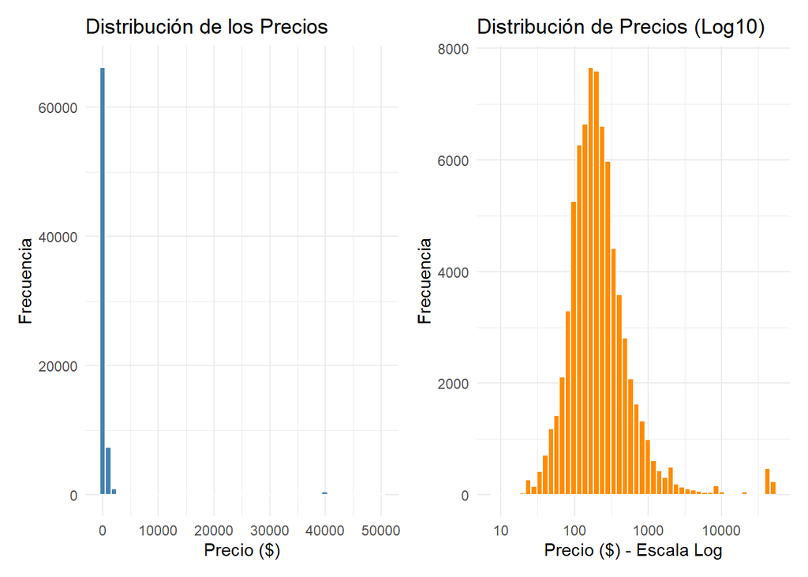

La distribución de la variable respuesta *price* presenta asimetría derecha: la mayor parte de las observaciones se concentran en el rango de precios bajos y medios, con una cola derecha extendida por propiedades de precio elevado. Dado que los modelos de regresión lineal suelen asumir aproximación a la normalidad de la variable dependiente (o de sus residuos), se evaluó la transformación logarítmica; en escala log10 la distribución se aproxima mejor a una forma unimodal y simétrica, lo que favorece el cumplimiento de supuestos y la estabilidad de las estimaciones en etapas posteriores.

### Pruebas de normalidad

```
##
##  Shapiro-Wilk normality test
##
## data:  precio_muestra
## W = 0.12329, p-value < 2.2e-16
```

```
##
##  Shapiro-Wilk normality test
##
## data:  precio_log_muestra
## W = 0.87843, p-value < 2.2e-16
```

En la escala original, la prueba de Shapiro-Wilk rechaza la hipótesis nula de normalidad (p < 0,05), coherente con la asimetría observada. Tras la transformación logarítmica, la distribución de *log(price)* se acerca más a la normalidad; no obstante, en muestras grandes incluso desviaciones moderadas suelen llevar al rechazo del test. La conclusión operativa es que, para el modelado de regresión, resulta preferible utilizar *price* en escala logarítmica cuando se busque mayor aproximación a los supuestos de normalidad de los residuos y estabilidad de la varianza; en el análisis exploratorio se mantiene la inspección visual de ambas escalas.

## Matriz de correlación

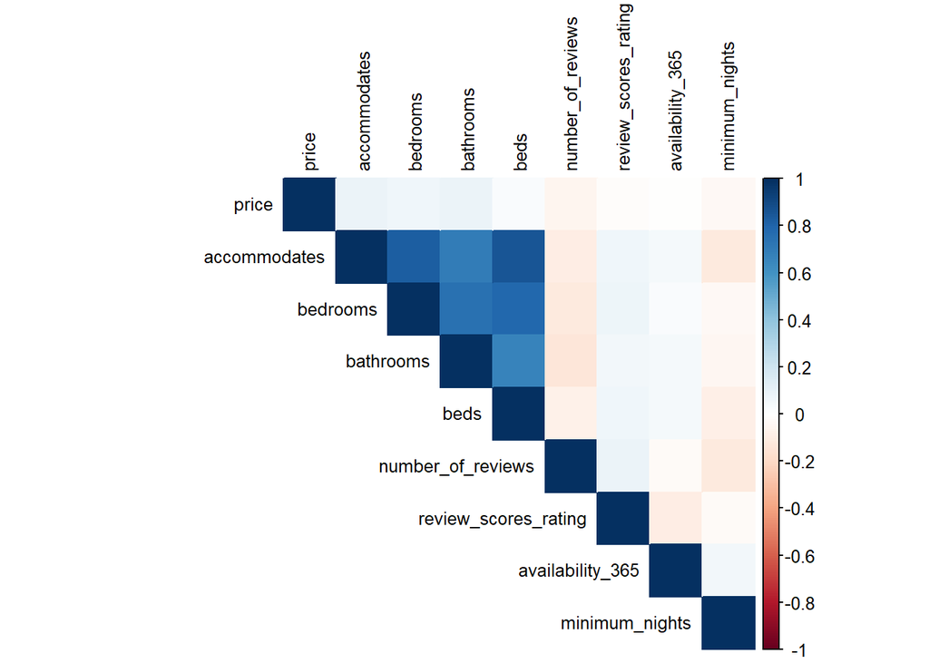

## Relación de la variable respuesta con los predictores

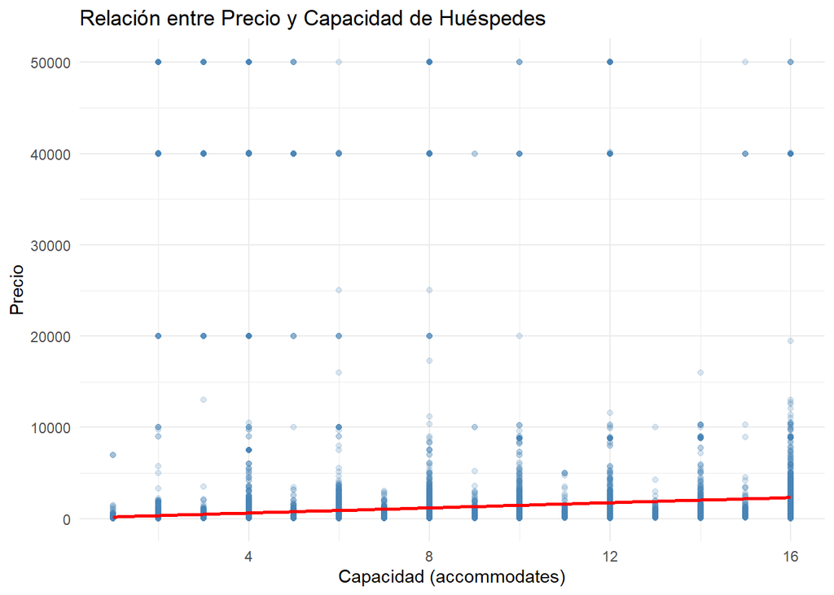

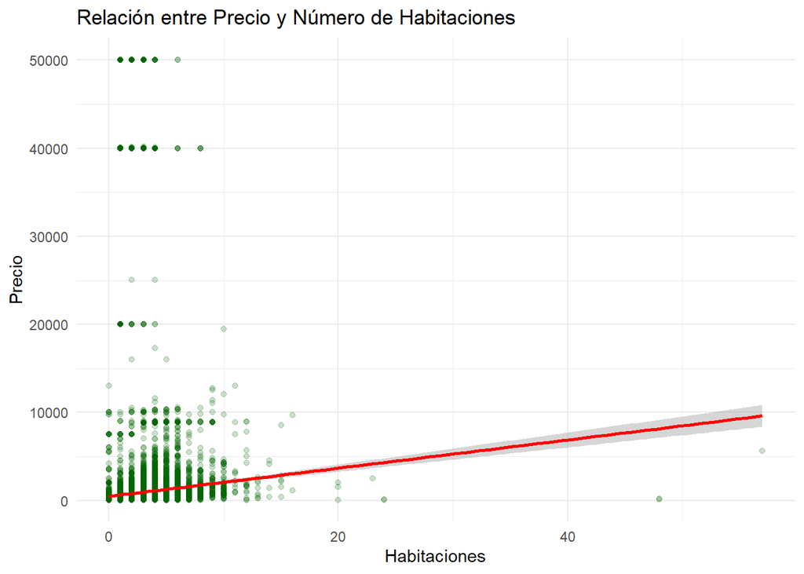

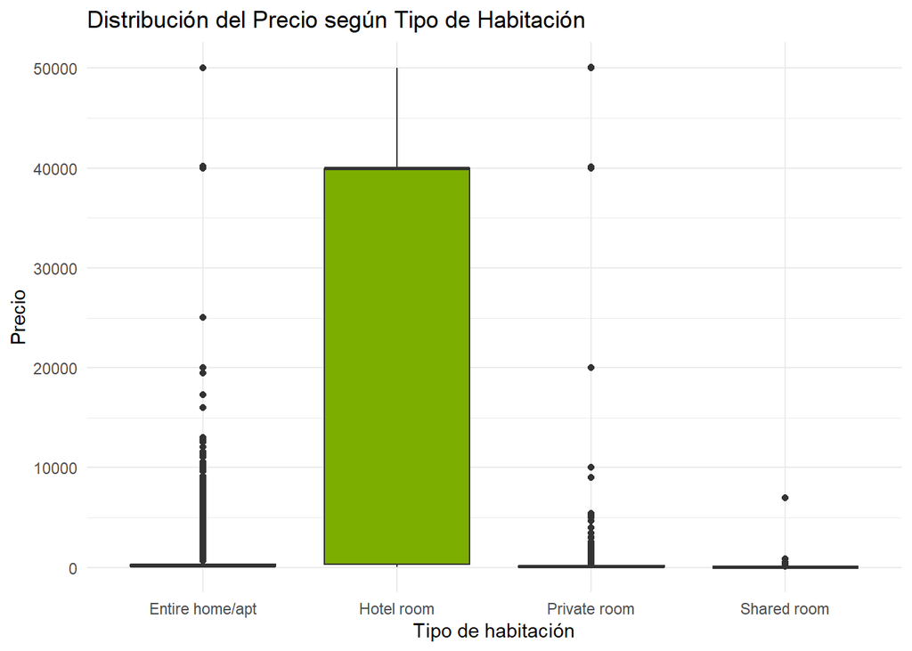

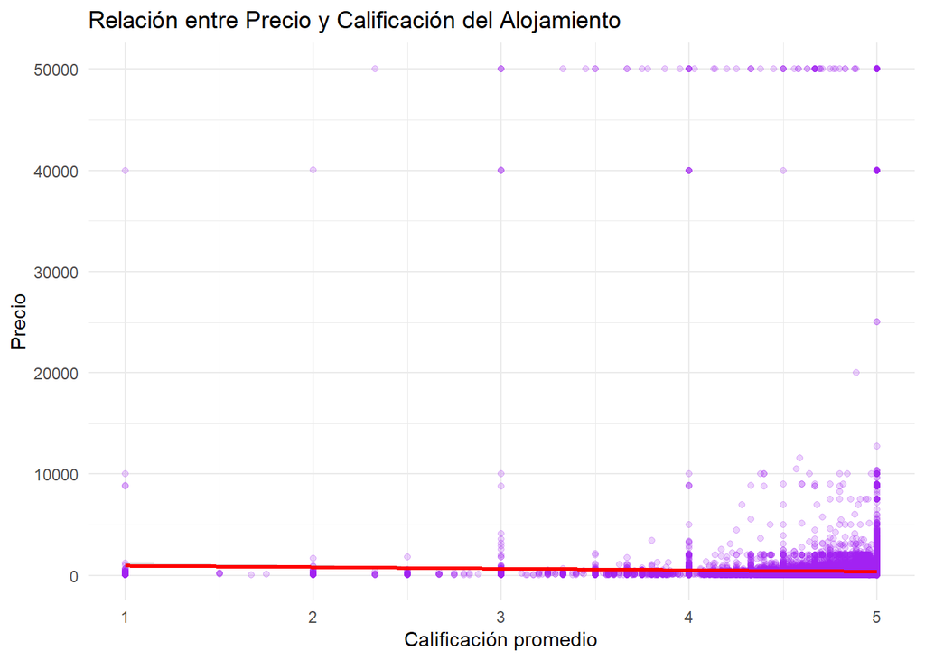

La matriz de correlación permite cuantificar las asociaciones lineales entre la variable respuesta (*price*) y un conjunto de predictores numéricos candidatos (capacidad, habitaciones, baños, camas, reseñas, calificación, disponibilidad y mínimo de noches). Los coeficientes obtenidos orientan la selección de variables y alertan sobre posibles redundancias antes de ajustar modelos de regresión múltiple.

Los gráficos bivariados complementan dicho análisis: se observa una relación positiva entre el precio y la capacidad de huéspedes (*accommodates*) y el número de habitaciones (*bedrooms*), coherente con la hipótesis de que la oferta de espacio condiciona el precio. La variable categórica *room_type* muestra una clara heterogeneidad en la distribución del precio: los alojamientos de vivienda completa presentan medianas y dispersiones superiores a las de habitaciones privadas o compartidas. La relación entre *review_scores_rating* y precio es más tenue en términos lineales, lo que sugiere que la calificación podría actuar como moderador o requerir especificaciones no lineales en modelos posteriores. En conjunto, estos hallazgos fundamentan la inclusión de variables estructurales y de tipo de alojamiento como predictores prioritarios para la predicción del precio.

## Clustering

```
## [1] "Estadístico de Hopkins: 0.981"
```

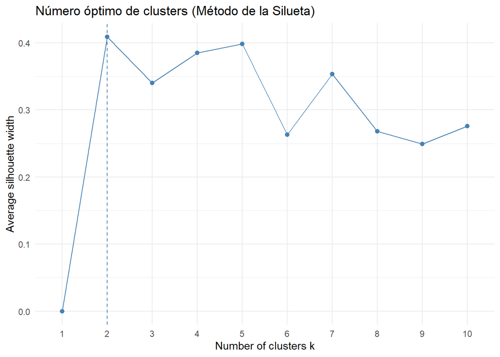

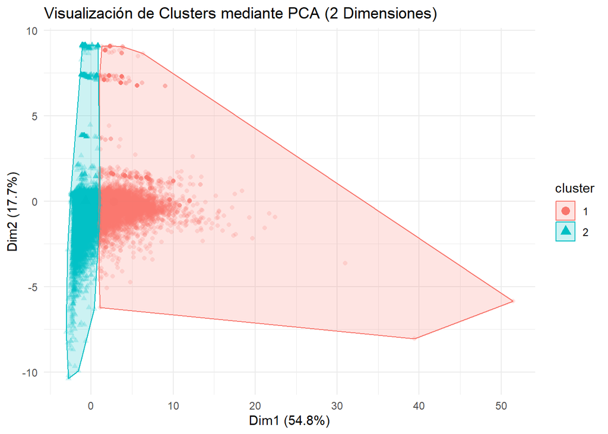

```
##   cluster size ave.sil.width
## 1       1  584          0.26
## 2       2 2416          0.51
```

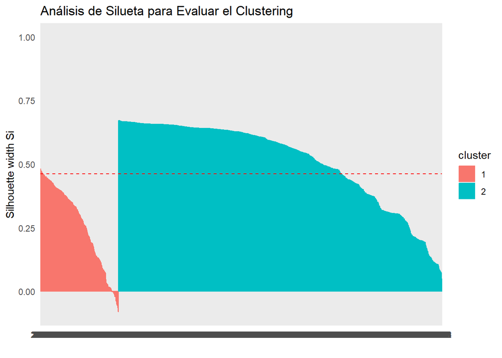

Como parte del análisis exploratorio se aplicó agrupamiento no supervisado (K-means) para identificar perfiles homogéneos en el conjunto de propiedades. Se seleccionaron variables de capacidad estructural (precio, accommodates, bedrooms, bathrooms, beds) y de popularidad (number_of_reviews), normalizadas mediante estandarización (media 0, desviación típica 1) para evitar que las diferencias de escala dominen la métrica de distancia. La viabilidad del clustering se evaluó en una muestra de 3.000 registros (estadístico de Hopkins, método de la silueta para elegir *k*); el número óptimo de clusters resultó ser 2, y el K-means se ajustó al conjunto completo para obtener las asignaciones definitivas.

En la muestra de evaluación, el grupo minoritario (cluster 1, *n* ≈ 584) presenta un coeficiente de silueta de aproximadamente 0,26, indicando cohesión moderada y cierto solapamiento con el otro grupo; el grupo mayoritario (cluster 2, *n* ≈ 2.416) alcanza una silueta de aproximadamente 0,51, lo que refleja una estructura más compacta y mejor separación. La interpretación de estos dos clusters se detalla a continuación a partir de los promedios por grupo.

```
## # A tibble: 2 × 4
##   cluster precio_promedio capacidad_promedio reviews_promedio
##   <fct>             <dbl>              <dbl>            <dbl>
## 1 1                 1304.               9.29             39.7
## 2 2                  609.               3.70             58.4
```

El resumen por cluster (precio medio, capacidad media, reseñas medias) permite caracterizar los perfiles obtenidos. El **cluster 2** (mayoritario) concentra propiedades de menor capacidad y precio más bajo (capacidad media cercana a 4 huéspedes, precio medio en torno a 608 USD/noche) y un volumen de reseñas mayor, coherente con una mayor rotación y un segmento más estándar del mercado. El **cluster 1** (minoritario) agrupa propiedades de mayor capacidad y precio notablemente superior (capacidad media superior a 9 huéspedes, precio medio por encima de 1.300 USD/noche), con menor número medio de reseñas, lo que es consistente con un segmento de alojamientos de mayor exclusividad y menor frecuencia de ocupación. Esta partición en dos perfiles (estándar vs. premium) resulta útil para el análisis exploratorio y puede informar estrategias de modelado diferenciadas o variables categóricas derivadas en la entrega final.

# Ejercicio 6: División de los datos (Entrenamiento y Prueba)

```
## [1] 53222    68
```

```
## [1] 22810    68
```

Conclusión del Ejercicio 6: Dividimos nuestra base de datos limpia en dos conjuntos: un 70% de las filas se utilizará para entrenar a nuestro modelo, y el 30% restante servirá como prueba para evaluar su capacidad de predicción. Fijamos una semilla inicial para garantizar que esta división aleatoria sea exactamente la misma cada vez que se ejecute el código, asegurando la reproducibilidad de la investigación.

# Ejercicio 7: Modelo Univariado de Regresión Lineal

```
##
## Call:
## lm(formula = price ~ accommodates, data = train)
##
## Residuals:
##    Min     1Q Median     3Q    Max
##  -2339   -619   -413   -224  49698
##
## Coefficients:
##              Estimate Std. Error t value Pr(>|t|)
## (Intercept)    46.735     34.567   1.352    0.176
## accommodates  143.764      6.069  23.688   <2e-16 ***
## ---
## Signif. codes:  0 '***' 0.001 '**' 0.01 '*' 0.05 '.' 0.1 ' ' 1
##
## Residual standard error: 4191 on 53220 degrees of freedom
## Multiple R-squared:  0.01043,    Adjusted R-squared:  0.01041
## F-statistic: 561.1 on 1 and 53220 DF,  p-value: < 2.2e-16
```

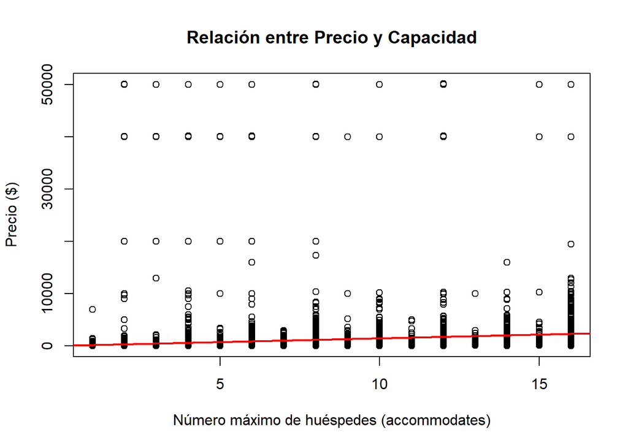

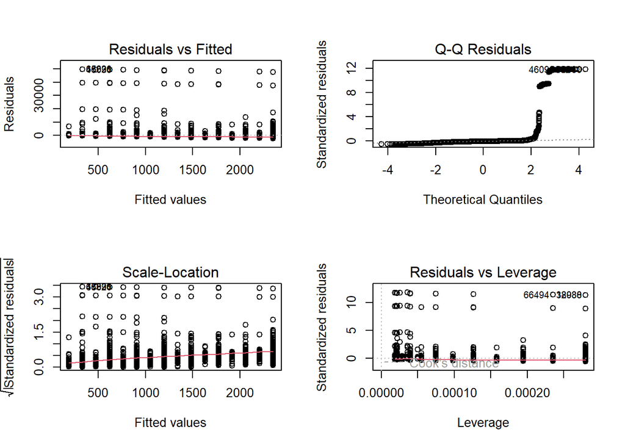

```
## [1] "Error Cuadrático Medio (MSE) Univariado: 18807594.94"
```

Elegimos la capacidad de huéspedes de la propiedad como variable principal para crear nuestro primer modelo simple. Al analizar los resultados y la gráfica, confirmamos la tendencia lógica: a mayor capacidad, el precio se incrementa. Evaluamos el error de esta predicción (MSE) para tener una línea base de comparación antes de avanzar a modelos más complejos.

# Ejercicio 8: Modelo Multivariado de Regresión Lineal

```
##
## Call:
## lm(formula = price ~ ., data = train_num)
##
## Residuals:
##    Min     1Q Median     3Q    Max
##  -7180   -804   -414    -47  68482
##
## Coefficients:
##                    Estimate Std. Error t value Pr(>|t|)
## (Intercept)        446.7607    55.4261   8.060 7.76e-16 ***
## accommodates       386.3737    11.6880  33.057  < 2e-16 ***
## bathrooms          334.7908    29.0474  11.526  < 2e-16 ***
## bedrooms           -60.0227    25.1165  -2.390   0.0169 *
## beds              -541.9503    14.9363 -36.284  < 2e-16 ***
## minimum_nights      -6.8129     0.8298  -8.210 2.26e-16 ***
## availability_365    -1.5954     0.1675  -9.524  < 2e-16 ***
## number_of_reviews   -2.6752     0.1889 -14.165  < 2e-16 ***
## ---
## Signif. codes:  0 '***' 0.001 '**' 0.01 '*' 0.05 '.' 0.1 ' ' 1
##
## Residual standard error: 4118 on 53214 degrees of freedom
## Multiple R-squared:  0.04463,    Adjusted R-squared:  0.04451
## F-statistic: 355.2 on 7 and 53214 DF,  p-value: < 2.2e-16
```

```
## [1] "MSE Entrenamiento: 16955951.23"
```

```
## [1] "MSE Prueba: 17893524.73"
```

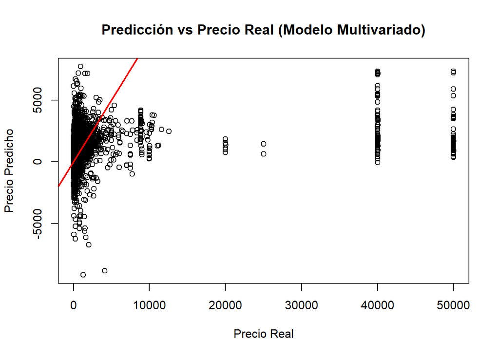

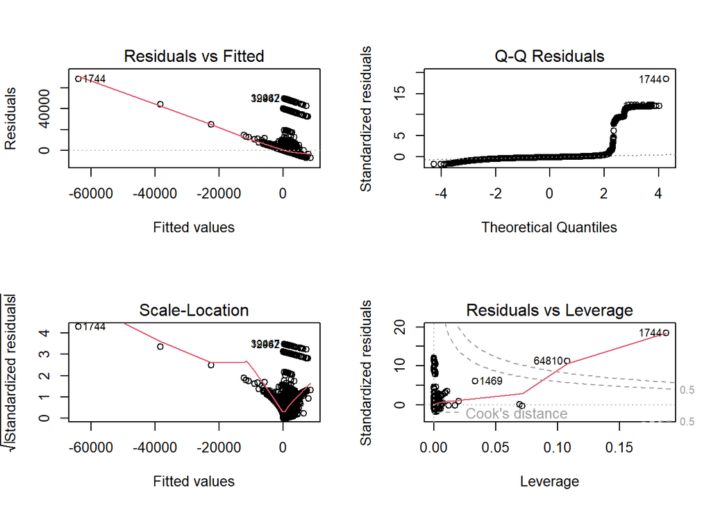

En este paso, el modelo tomó en cuenta múltiples características de infraestructura y popularidad a la vez para intentar estimar el precio de manera más precisa. Al comparar gráficamente la predicción con el precio real, observamos qué tanto se ajustan nuestros cálculos a la realidad. Además, calculamos los errores en ambas fases (entrenamiento y prueba) para evaluar el aprendizaje general del algoritmo

# Ejercicio 9: Análisis del Modelo y Multicolinealidad

```
##      accommodates         bathrooms          bedrooms              beds
##          3.841102          2.561195          3.788340          3.202516
##    minimum_nights  availability_365 number_of_reviews
##          1.054804          1.010508          1.037043
```

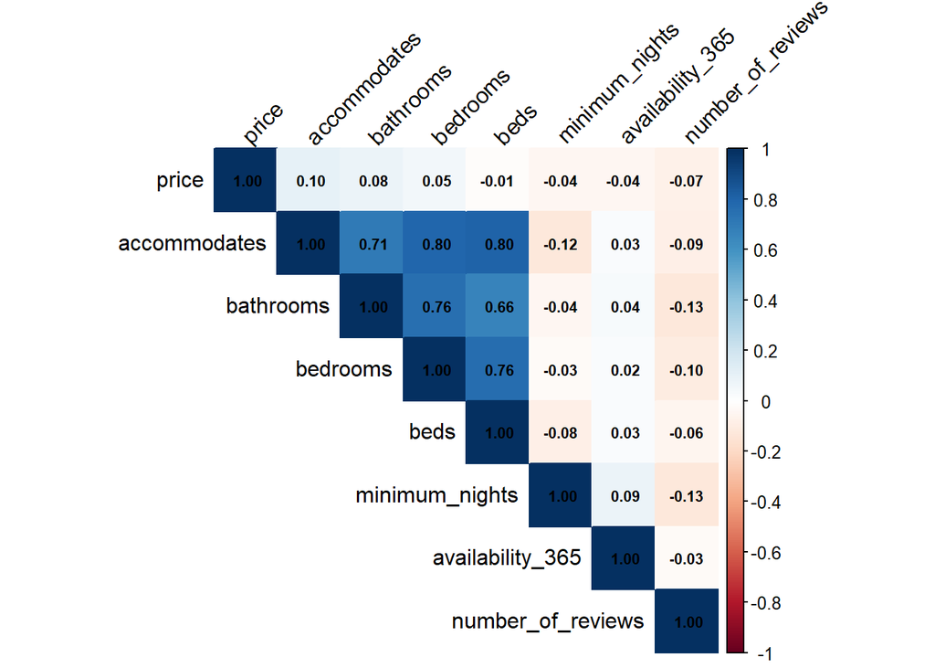

```
##
## Call:
## lm(formula = price ~ accommodates + bathrooms + number_of_reviews +
##     availability_365, data = train_num)
##
## Residuals:
##    Min     1Q Median     3Q    Max
##  -2436   -701   -440   -185  50034
##
## Coefficients:
##                   Estimate Std. Error t value Pr(>|t|)
## (Intercept)       601.6425    54.9467  10.950   <2e-16 ***
## accommodates      122.4993     8.5657  14.301   <2e-16 ***
## bathrooms          65.7600    26.1914   2.511   0.0121 *
## number_of_reviews  -2.7445     0.1898 -14.461   <2e-16 ***
## availability_365   -1.7708     0.1692 -10.463   <2e-16 ***
## ---
## Signif. codes:  0 '***' 0.001 '**' 0.01 '*' 0.05 '.' 0.1 ' ' 1
##
## Residual standard error: 4178 on 53217 degrees of freedom
## Multiple R-squared:  0.01642,    Adjusted R-squared:  0.01635
## F-statistic: 222.2 on 4 and 53217 DF,  p-value: < 2.2e-16
```

```
## [1] "MSE Modelo Reducido: 18709759.86"
```

Evaluamos si nuestro modelo contenía variables que aportaban información repetida (multicolinealidad). Al revisar las métricas y la matriz de correlación, notamos que características como el número de camas, las habitaciones y la capacidad total están altamente vinculadas entre sí, ya que esencialmente miden el mismo aspecto del tamaño de la vivienda

Asimismo, al comparar los errores del conjunto de prueba y el de entrenamiento, notamos resultados bastante parecidos, lo que nos permite concluir que el modelo no sufre de un sobreajuste severo (overfitting). De todas formas, construimos un modelo reducido eliminando las variables que causaban redundancia para lograr una predicción más estable y limpia

# Ejercicio 10: Modelo Óptimo y Análisis de Residuos

```
##
## Call:
## lm(formula = price ~ accommodates + bathrooms + number_of_reviews +
##     room_type, data = train)
##
## Residuals:
##    Min     1Q Median     3Q    Max
## -25435   -517   -211     21  49923
##
## Coefficients:
##                         Estimate Std. Error t value Pr(>|t|)
## (Intercept)            -238.6946    36.5385  -6.533 6.52e-11 ***
## accommodates            129.0220     7.7403  16.669  < 2e-16 ***
## bathrooms               101.0999    22.7091   4.452 8.53e-06 ***
## number_of_reviews        -1.6737     0.1632 -10.253  < 2e-16 ***
## room_typeHotel room   23575.7489   171.3901 137.556  < 2e-16 ***
## room_typePrivate room   690.7632    49.5419  13.943  < 2e-16 ***
## room_typeShared room    -38.9255   309.5955  -0.126      0.9
## ---
## Signif. codes:  0 '***' 0.001 '**' 0.01 '*' 0.05 '.' 0.1 ' ' 1
##
## Residual standard error: 3590 on 53215 degrees of freedom
## Multiple R-squared:  0.2739, Adjusted R-squared:  0.2738
## F-statistic:  3345 on 6 and 53215 DF,  p-value: < 2.2e-16
```

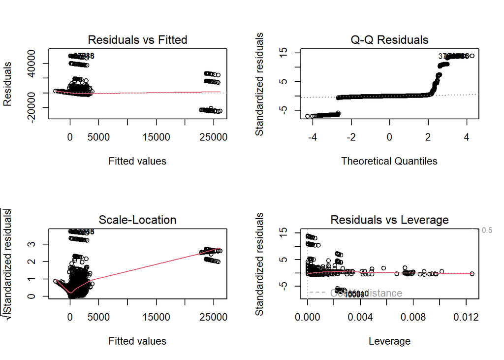

Para corregir la multicolinealidad detectada, construimos un modelo óptimo seleccionando únicamente las variables más determinantes y evitando redundancias: la capacidad total (accommodates), el número de baños, el tipo de habitación y la cantidad de reseñas.

Al observar los gráficos de residuos, notamos que los errores no se distribuyen de manera perfectamente aleatoria, especialmente en los extremos, lo que indica que aún existen valores atípicos (propiedades excesivamente caras) que el modelo lineal estándar no logra capturar bien.

# Ejercicio 11: Modelo con Regularización (Lasso)

```
## El mejor valor de lambda encontrado es: 6.713731
```

```
## Error Cuadrático Medio (MSE) Lasso: 13320844
```

Para evitar el sobreajuste y mejorar la capacidad de generalización, aplicamos el algoritmo de regularización Lasso. Este método penaliza las variables menos útiles llevándolas a cero, dejándonos solo con las más importantes. Tras aplicar validación cruzada, el algoritmo determinó que el nivel de penalización óptimo (lambda) era de 6.71. Al evaluar este modelo con nuestros datos de prueba, obtuvimos un Error Cuadrático Medio (MSE) de 13,320,844

# Ejercicios 12 y 13: Comparación de Modelos

```
##                    Modelo      MSE
## 1              Univariado 18807595
## 2 Multivariado (Completo) 17893525
## 3   Multivariado (Óptimo) 13318980
## 4                   Lasso 13320844
```

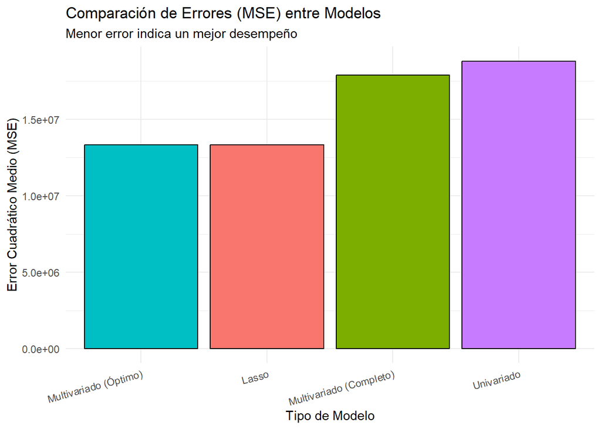

Para determinar la eficiencia de nuestros algoritmos, utilizamos el Error Cuadrático Medio (MSE) como métrica principal, la cual mide qué tan alejadas estuvieron nuestras predicciones de los precios reales en el conjunto de prueba. Los resultados muestran que el modelo Univariado tuvo el error más alto (18,807,595), lo cual era de esperarse al depender de una sola característica. El modelo Multivariado Completo mejoró ligeramente el desempeño (17,893,525), pero seguía afectado por información redundante.

# Discusión y Selección del Mejor Modelo:

Los mejores resultados se concentraron en los dos últimos modelos. El modelo Lasso logró reducir drásticamente el error a 13,320,844 al penalizar y descartar automáticamente las variables menos útiles. Sin embargo, el modelo Multivariado Óptimo (donde seleccionamos manualmente la capacidad, baños, cantidad de reseñas y tipo de habitación tras analizar la multicolinealidad) fue el ganador absoluto con el error más bajo de todos: 13,318,980.

En conclusión, para cumplir con el objetivo de SmartStay Advisors de estimar precios competitivos , la elección del mejor algoritmo predictivo recae en el modelo Multivariado Óptimo. Demostramos que una selección de variables fundamentada en el análisis exploratorio puede igualar o incluso superar a técnicas automáticas de regularización.

Como recomendación final para la consultoría, es importante destacar que los precios de los alojamientos en plataformas como Airbnb no siempre siguen un comportamiento estrictamente lineal. Aunque logramos reducir el error significativamente, para futuras implementaciones se sugiere explorar algoritmos no lineales (como árboles de decisión) que puedan capturar mejor el impacto de los barrios específicos y la estacionalidad para lograr estimaciones aún más precisas.